# Fantasy Football League Report

Dusty Turner

04 October 2019

# League Update

Hello all, welcome to OA Division Fantasy Football Week 4 Update!

## Mug (and Plunger) Standings

Mug: Everyone congratulate Palindrome Tikkit for winning the mug.

Plunger: Hardy cajoling goes out to Philly Chapmaniacs for earning the plunger this week. Hats off for your hard work!

Current Mug tally:

| Award | Team | n |
| --- | --- | --- |
| Mug | ’R’m Chair Quarterback | 1 |
| Mug | Palindrome Tikkit | 1 |
| Mug | The Chief | 1 |
| Mug | The OBJective Functions | 1 |

Current Plunger tally:

| Award | Team | n |
| --- | --- | --- |
| Plunger | Philly Chapmaniacs | 2 |
| Plunger | Dallas The boys | 1 |
| Plunger | The Plainsmen | 1 |

## Standings

The standings are current through week 4.

Every week wins are how many wins your team would have if you played every team every week.

Every week losses and every week win percentage are calculated accordingly.

This is meant to be a measure of how ‘lucky’ your team is.

|  | Team | Wins | Losses | WinPerc | EveryWeekWins | EveryWeekLosses | EveryWeekPerc |
| --- | --- | --- | --- | --- | --- | --- | --- |
| 1 | Compute This! | 4 | 0 | 1 | 26 | 10 | 0.72 |
| 2 | The Chief | 3 | 1 | 0.75 | 25 | 11 | 0.69 |
| 3 | Philly Chapmaniacs | 2 | 2 | 0.5 | 13 | 23 | 0.36 |
| 4 | The Plainsmen | 2 | 2 | 0.5 | 20 | 16 | 0.56 |
| 5 | Team Ward | 2 | 2 | 0.5 | 15.5 | 20.5 | 0.43 |
| 6 | Palindrome Tikkit | 2 | 2 | 0.5 | 22 | 14 | 0.61 |
| 7 | Analysis Paralysis | 2 | 2 | 0.5 | 16 | 20 | 0.44 |
| 8 | 'R'm Chair Quarterback | 1 | 3 | 0.25 | 17 | 19 | 0.47 |
| 9 | Dallas The boys | 1 | 3 | 0.25 | 8 | 28 | 0.22 |
| 10 | The OBJective Functions | 1 | 3 | 0.25 | 17.5 | 18.5 | 0.49 |

A graphical view of the above information. Low and right are lucky. Up and left are unlucky.

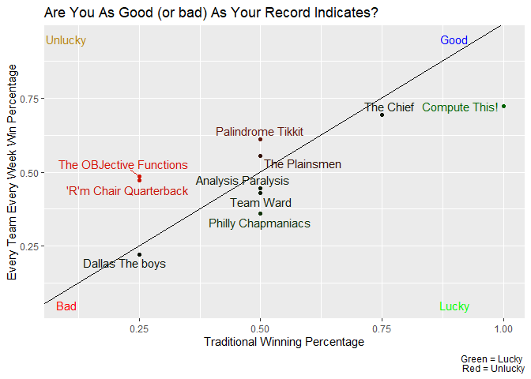

## Expected Points

### What Teams Are Living Up to Expectations This Week?

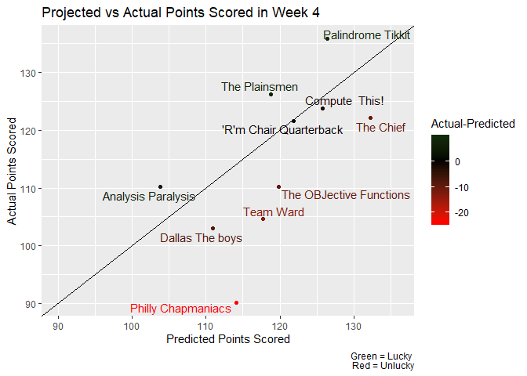

### What Teams Are Living Up to Expectations All Weeks?

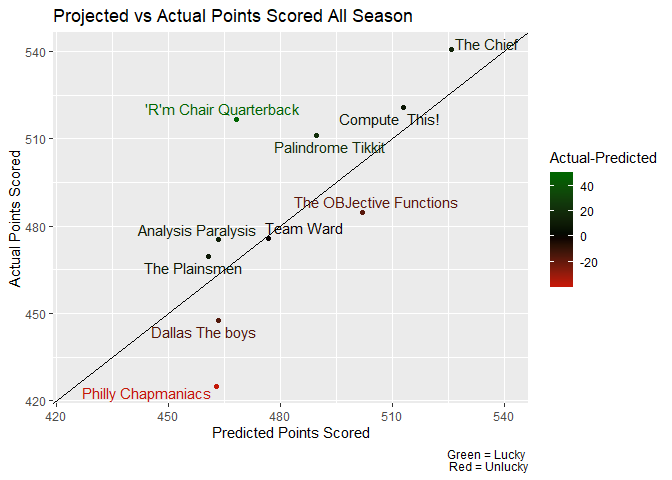

### Whose Team’s Starters Are Meeting Expectations?

This table shows the Team’s starter’s actual points scored minus their projected points scored in week 4.

|  | Team | Delta |
| --- | --- | --- |
| 1 | Philly_Chapmaniacs | -23.97 |
| 2 | Team_Ward | -13.15 |
| 3 | The_Chief | -10.1 |
| 4 | The OBJective_Functions | -9.56 |
| 5 | Dallas_The boys | -7.97 |
| 6 | Compute _This! | -1.97 |
| 7 | 'R'm Chair_Quarterback | -0.18 |
| 8 | Analysis_Paralysis | 6.33 |
| 9 | The_Plainsmen | 7.52 |
| 10 | Palindrome_Tikkit | 9.45 |

This table show’s how each team’s starters have actually performed vs their projection (on average) all season.

|  | Team | Delta |
| --- | --- | --- |
| 1 | Philly_Chapmaniacs | -37.98 |
| 2 | The OBJective_Functions | -17.41 |
| 3 | Dallas_The boys | -15.71 |
| 4 | Team_Ward | -0.93 |
| 5 | Compute _This! | 7.63 |
| 6 | The_Plainsmen | 9.15 |
| 7 | Analysis_Paralysis | 11.91 |
| 8 | The_Chief | 14.8 |
| 9 | Palindrome_Tikkit | 21.57 |
| 10 | 'R'm Chair_Quarterback | 48.53 |

## Optimal Lineup

Who is the best coach? How much have you missed your optimal line up this week?

The plot below reflects how many points you scored vs your best line up.

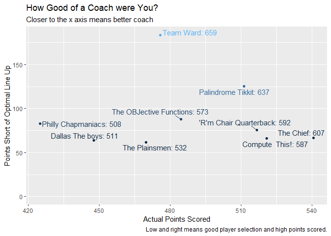

How good of a coach were you in week 4?

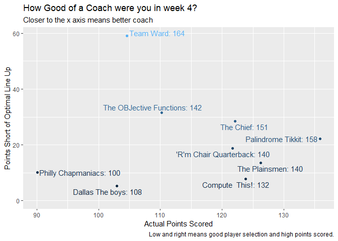

### What if you played your best roster each week?

The following table shows how well your team could be doing if you played your best roster every week.

|  | Team | Wins | Losses | WinPerc |
| --- | --- | --- | --- | --- |
| 1 | Team Ward | 4 | 0 | 1 |
| 2 | Palindrome Tikkit | 3 | 1 | 0.75 |
| 3 | Compute This! | 3 | 1 | 0.75 |
| 4 | Philly Chapmaniacs | 2 | 2 | 0.5 |
| 5 | 'R'm Chair Quarterback | 2 | 2 | 0.5 |
| 6 | Analysis Paralysis | 2 | 2 | 0.5 |
| 7 | The Plainsmen | 1 | 3 | 0.25 |
| 8 | Dallas The boys | 1 | 3 | 0.25 |
| 9 | The OBJective Functions | 1 | 3 | 0.25 |
| 10 | The Chief | 1 | 3 | 0.25 |

## A Look Across the League:

### What Positions Are Predicted Most Accurately

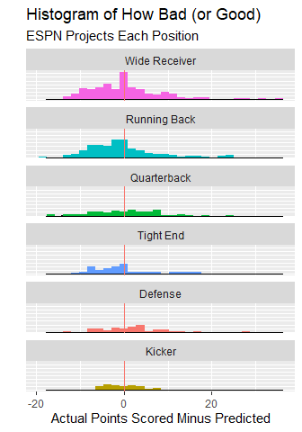

## Performance By Position Compared To Other Teams

[interactive chart not shown]